# Pricing Optimization for PalletTrader

Ife Abe

2025-01-06

# 1 Introduction

PalletTrader is an online marketplace for buyers and sellers of pallets. This case study demonstrates pricing optimization to maximize profit for PalletTrader while considering production capacity, demand, and other constraints.

# 2 Objective

# 3 Step 1: Generate Data

First, we simulate a dataset for PalletTrader’s pricing optimization.

```r
# Simulated profit per pallet (in dollars)
profit_per_pallet <- c(
  recycled = sample(8:12, 1),  # Profit for recycled pallets
  new = sample(13:18, 1)       # Profit for new pallets
)

# Constraints: Supply availability and buyer demand
supply_capacity <- 1000  # Total pallets available (Recycled + New)
min_recycled_demand <- 300   # Minimum demand for recycled pallets
min_new_demand <- 400        # Minimum demand for new pallets

# Display generated data
data <- data.frame(
  Type = c("Recycled", "New"),
  Profit = profit_per_pallet,
  MinDemand = c(min_recycled_demand, min_new_demand)
)
data
```

```
##              Type Profit MinDemand
## recycled Recycled     10       300
## new           New     18       400
```

# 4 Step 2: Define the Pricing Optimization Problem

We define the objective function and constraints for the linear programming problem.

```r
# Objective function: Profit per pallet
objective <- profit_per_pallet

# Constraint matrix
constraints <- matrix(c(
  1, 1,  # Total supply constraint (Recycled + New <= 1000)
  1, 0,  # Minimum recycled demand (Recycled >= 300)
  0, 1   # Minimum new demand (New >= 400)
), nrow = 3, byrow = TRUE)

# Right-hand side of constraints
rhs <- c(supply_capacity, min_recycled_demand, min_new_demand)

# Directions of constraints
directions <- c("<=", ">=", ">=")
```

# 5 Step 3: Solve the Optimization Problem

We use the `lpSolve` package to solve the linear programming problem.

```r
# Solve the linear programming problem
solution <- lp(
  direction = "max",       # Maximize profit
  objective.in = objective,
  const.mat = constraints,
  const.dir = directions,
  const.rhs = rhs
)

# Display the results
if (solution$status == 0) {
  cat("**Optimal Solution Found:**\n")
  cat("Recycled pallets to supply:", solution$solution[1], "\n")
  cat("New pallets to supply:", solution$solution[2], "\n")
  cat("Maximum Profit:", solution$objval, "\n")
} else {
  cat("No Optimal Solution Found")
}
```

```
## **Optimal Solution Found:**
## Recycled pallets to supply: 300
## New pallets to supply: 700
## Maximum Profit: 15600
```

# 6 Step 4: Visualize the Results

We visualize the optimized solution to communicate insights effectively.

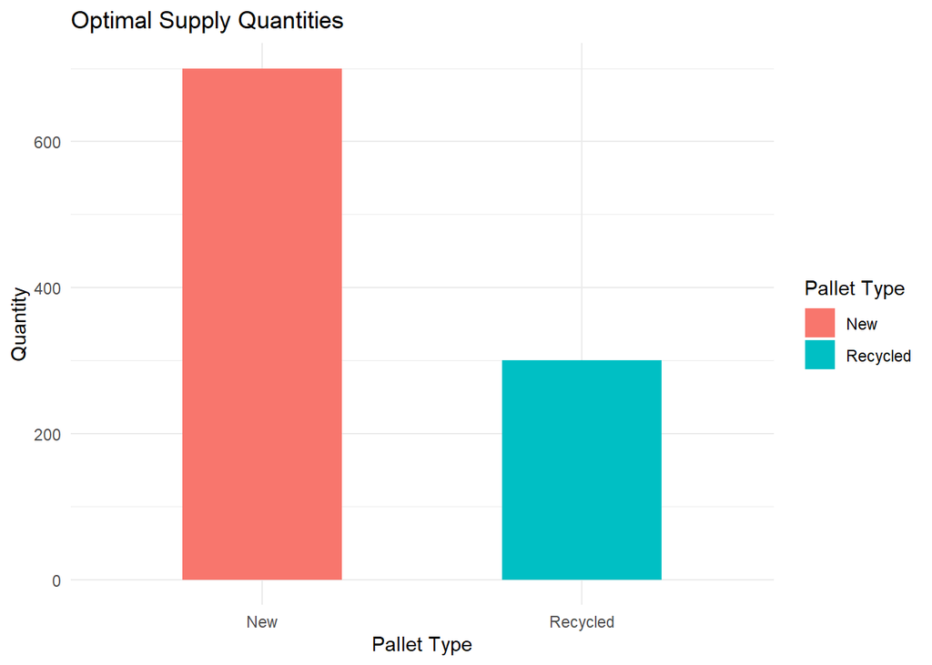

# 7 Conclusion

After analyzing the data and running the optimization model, here are the key findings:

1. **How Many Pallets to Sell:**
   - **300 recycled pallets** should be sold.
   - **700 new pallets** should be sold.

   This combination ensures PalletTrader meets the demand for both types of pallets while aligning with its operational constraints and sustainability goals.
2. **Profit Maximization:**
   - By selling this optimal mix of pallets, PalletTrader can achieve a **maximum profit of $15,600**.
   - This means that after accounting for costs, the company will earn the highest possible return by following this strategy.
3. **Why This Solution Works:**
   - Selling 300 recycled pallets ensures that PalletTrader meets the minimum demand for recycled pallets while promoting sustainability.
   - Selling 700 new pallets meets the higher demand for new pallets, which are priced higher and contribute significantly to revenue.
   - The combination balances customer demand, supply limits, and pricing, maximizing profits while ensuring the business remains competitive.

### 7.0.1 **What Does This Mean for PalletTrader?**

- **Balanced Strategy:** This plan balances **profitability** and **sustainability**, which is key for PalletTrader as an online marketplace.
- **Meeting Customer Needs:** Customers demanding both recycled and new pallets are satisfied, ensuring business continuity and loyalty.
- **Sustainability Goals:** By selling recycled pallets, PalletTrader maintains its commitment to environmentally friendly practices.
- **Financial Growth:** This strategy ensures that the company maximizes its earnings, helping it reinvest in the platform and grow its market share.

### 7.0.2 **Takeaway for Decision-Makers**

By following this pricing strategy, PalletTrader will meet customer demand, support sustainability efforts, and achieve the best financial outcome. It’s a win-win solution for both the company and its stakeholders!